# study1 preprocessing

anonymous

2024-12-10

```r
knit_by_pkgdown <- !is.null(knitr::opts_chunk$get("fig.retina"))
knitr::opts_chunk$set(
  warning = TRUE, # show warnings during codebook generation
  message = TRUE, # show messages during codebook generation
  error = TRUE, # do not interrupt codebook generation in case of errors,
                # TRUE is usually better for debugging
  echo = TRUE  # show R code
)

library(pacman)
pacman::p_load(tidyverse, labelled, here, codebook)
ggplot2::theme_set(ggplot2::theme_bw())
```

# 1 Read data

```r
codebook::codebook(d)
```

### 1.0.1 Metadata

#### 1.0.1.1 Description

**Dataset name**: Raw data for Study 1

This is the raw dataset for study 1 that will be used as input for the pre-processing script. Since this data is not yet preprocessed, and many of the variables are directly created by jspsych, the variables may not be immediately interpretable or relevant. There are 50 subject rows, and 24 rows per subject. Each row represents a jspsych trial.

**Metadata for search engines**

- **Date published**: 2025-02-03

| x |
| --- |
| subject_id |
| trial_type |
| trial_index |
| plugin_version |
| time_elapsed |
| trial_id |
| rt |
| stimulus |
| response |
| view_history |
| init_locations |
| moves |
| final_locations |
| 0 |
| 1 |
| 2 |
| 3 |
| 4 |
| 5 |
| 6 |
| 7 |
| 8 |
| 9 |
| 10 |
| 11 |
| 12 |
| 13 |
| 14 |
| question_order |
| 15 |
| feedback |
| age |
| ethnicity |
| gender |
| race |

## 1.1 Variables

### 1.1.1 subject_id

Subject ids for all 50 subjects

#### 1.1.1.1 Distribution

```
## 50  unique, categorical values, so not shown.
```

0 missing values.

#### 1.1.1.2 Summary statistics

| name | label | data_type | ordered | value_labels | n_missing | complete_rate | n_unique | top_counts |
| --- | --- | --- | --- | --- | --- | --- | --- | --- |
| subject_id | Subject ids for all 50 subjects | factor | FALSE | 1. subj_01, 2. subj_02, 3. subj_03, 4. subj_04, 5. subj_05, 6. subj_06, 7. subj_07, 8. subj_08, 9. subj_09, 10. subj_10, 11. subj_11, 12. subj_12, 13. subj_13, 14. subj_14, 15. subj_15, 16. subj_16, 1… | 0 | 1 | 50 | sub: 24, sub: 24, sub: 24, sub: 24 |

### 1.1.2 trial_type

Type of jspsych trial. Trials in jspsych represent checkpoints in the experiment, such as the instructions page, the survey page etc

#### 1.1.2.1 Distribution

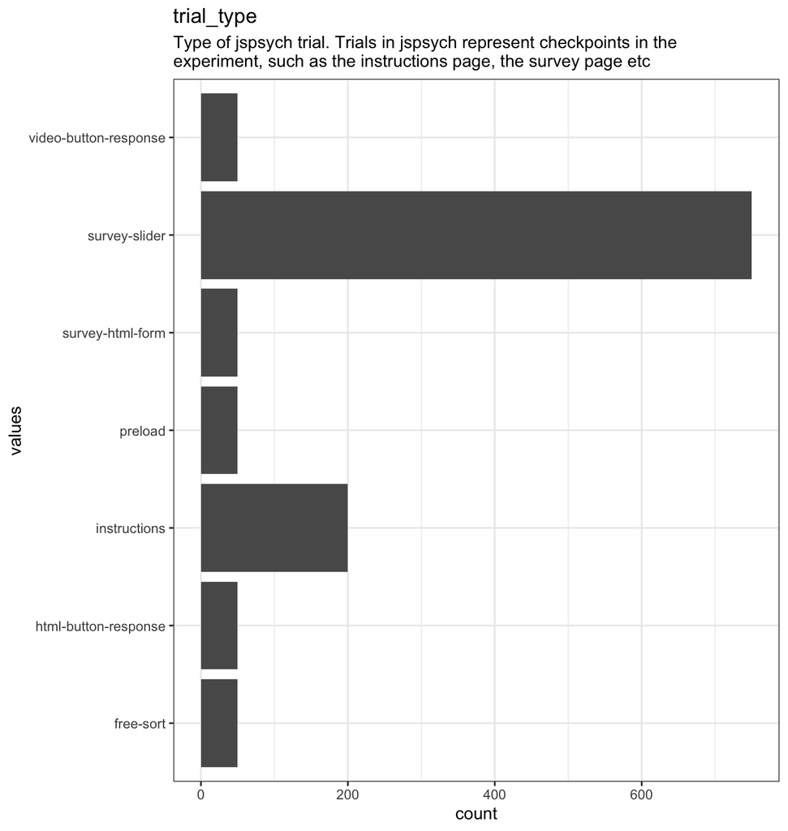

Distribution of values for trial_type

0 missing values.

#### 1.1.2.2 Summary statistics

| name | label | data_type | n_missing | complete_rate | n_unique | empty | min | max | whitespace |
| --- | --- | --- | --- | --- | --- | --- | --- | --- | --- |
| trial_type | Type of jspsych trial. Trials in jspsych represent checkpoints in the experiment, such as the instructions page, the survey page etc | character | 0 | 1 | 7 | 0 | 7 | 21 | 0 |

### 1.1.3 trial_index

#### 1.1.3.1 Distribution

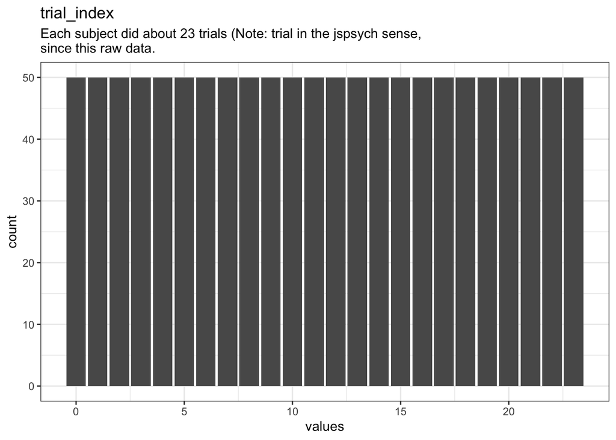

Distribution of values for trial_index

0 missing values.

#### 1.1.3.2 Summary statistics

[output not shown]

### 1.1.4 plugin_version

Plugin version that the subject had for the jspsych trials

#### 1.1.4.1 Distribution

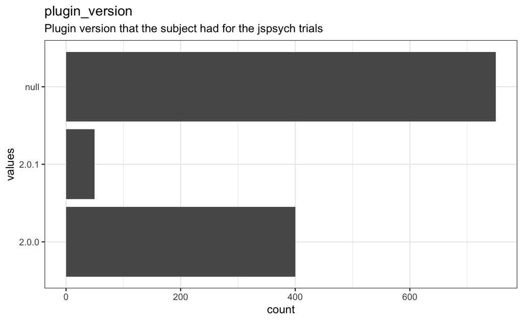

Distribution of values for plugin_version

0 missing values.

#### 1.1.4.2 Summary statistics

| name | label | data_type | n_missing | complete_rate | n_unique | empty | min | max | whitespace |
| --- | --- | --- | --- | --- | --- | --- | --- | --- | --- |
| plugin_version | Plugin version that the subject had for the jspsych trials | character | 0 | 1 | 3 | 0 | 4 | 5 | 0 |

### 1.1.5 time_elapsed

Time in milliseconds the subject spent on a given trial

#### 1.1.5.1 Distribution

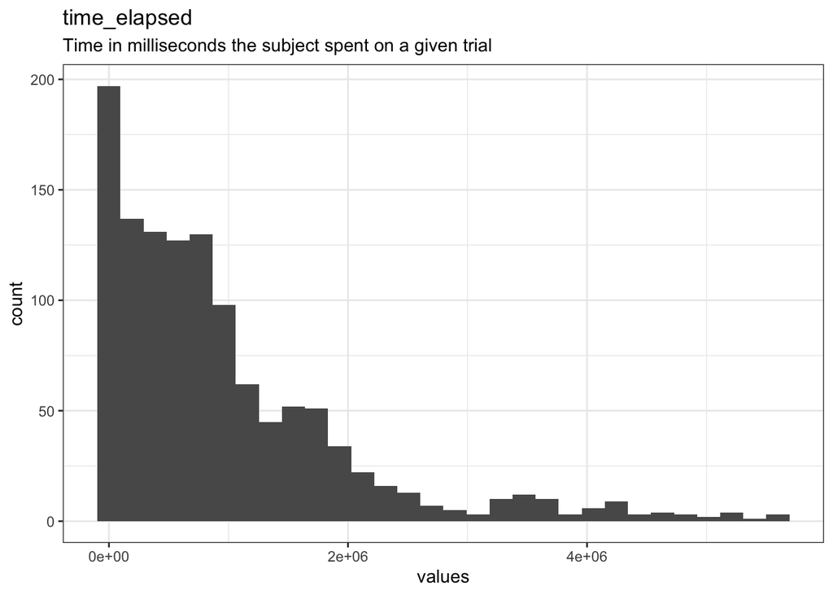

Distribution of values for time_elapsed

0 missing values.

#### 1.1.5.2 Summary statistics

| name | label | data_type | n_missing | complete_rate | min | median | max | mean | sd | hist |
| --- | --- | --- | --- | --- | --- | --- | --- | --- | --- | --- |
| time_elapsed | Time in milliseconds the subject spent on a given trial | numeric | 0 | 1 | 154 | 684924 | 5596441 | 965786.4 | 1025307 | ▇▂▁▁▁ |

### 1.1.6 trial_id

Researcher-assigned trial names. Trials highlighted were the consent, example_videos and demorgraphics_survey

#### 1.1.6.1 Distribution

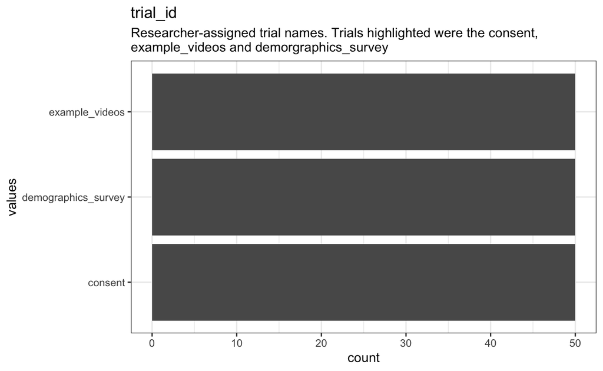

Distribution of values for trial_id

1050 missing values.

#### 1.1.6.2 Summary statistics

| name | label | data_type | n_missing | complete_rate | n_unique | empty | min | max | whitespace |
| --- | --- | --- | --- | --- | --- | --- | --- | --- | --- |
| trial_id | Researcher-assigned trial names. Trials highlighted were the consent, example_videos and demorgraphics_survey | character | 1050 | 0.125 | 3 | 0 | 7 | 19 | 0 |

### 1.1.7 rt

Time it takes in milliseconds from when the page loads to when subject clicks on continue button

#### 1.1.7.1 Distribution

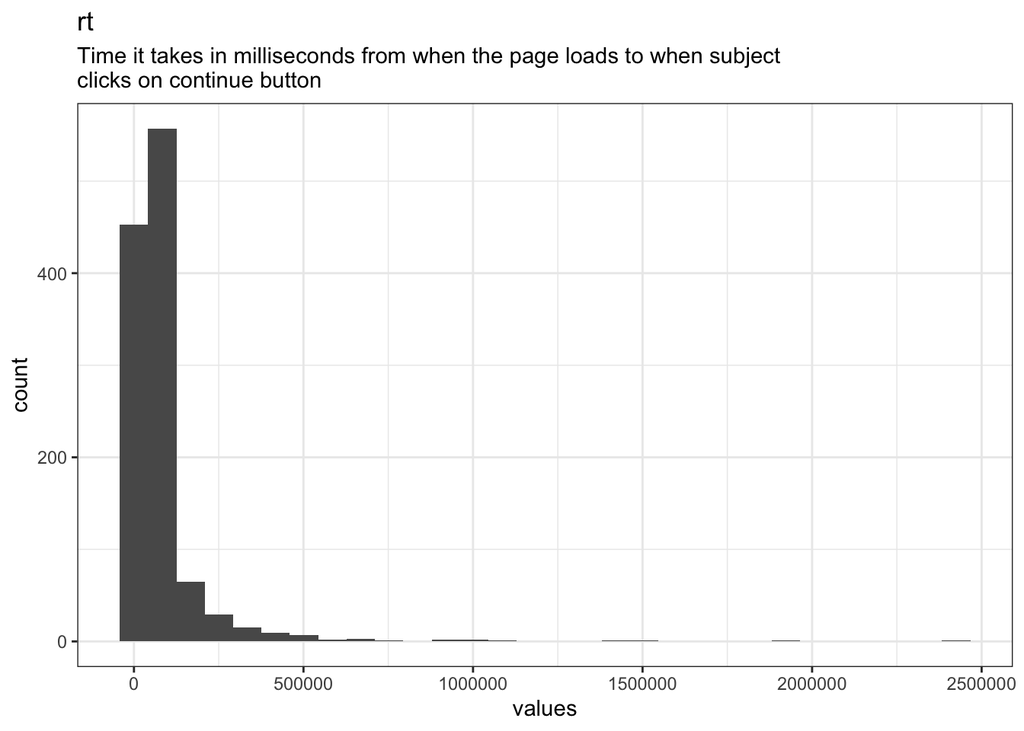

Distribution of values for rt

50 missing values.

#### 1.1.7.2 Summary statistics

| name | label | data_type | n_missing | complete_rate | min | median | max | mean | sd | hist |
| --- | --- | --- | --- | --- | --- | --- | --- | --- | --- | --- |
| rt | Time it takes in milliseconds from when the page loads to when subject clicks on continue button | numeric | 50 | 0.9583333 | 906 | 51539 | 2425768 | 83171.52 | 147934.4 | ▇▁▁▁▁ |

### 1.1.8 stimulus

Html-formatted string describing the stimulus presented to participant on trials that had a stimulus

#### 1.1.8.1 Distribution

[figure not shown]

Distribution of values for stimulus

1100 missing values.

#### 1.1.8.2 Summary statistics

| name | label | data_type | n_missing | complete_rate | n_unique | empty | min | max | whitespace |
| --- | --- | --- | --- | --- | --- | --- | --- | --- | --- |
| stimulus | Html-formatted string describing the stimulus presented to participant on trials that had a stimulus | character | 1100 | 0.0833333 | 2 | 0 | 35 | 1959 | 0 |

### 1.1.9 response

For the Causal Task, a dictionary containing subject responses for all 14 questions in each page

#### 1.1.9.1 Distribution

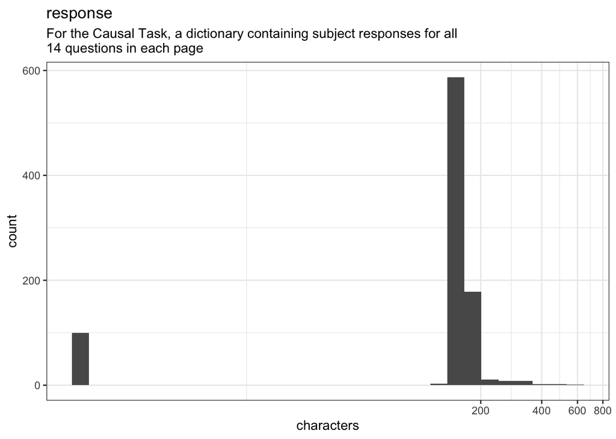

Distribution of values for response

300 missing values.

#### 1.1.9.2 Summary statistics

| name | label | data_type | n_missing | complete_rate | n_unique | empty | min | max | whitespace |
| --- | --- | --- | --- | --- | --- | --- | --- | --- | --- |
| response | For the Causal Task, a dictionary containing subject responses for all 14 questions in each page | character | 300 | 0.75 | 801 | 0 | 1 | 540 | 0 |

### 1.1.10 view_history

A dictionary containing the index of the page and viewing time in milliseconds

#### 1.1.10.1 Distribution

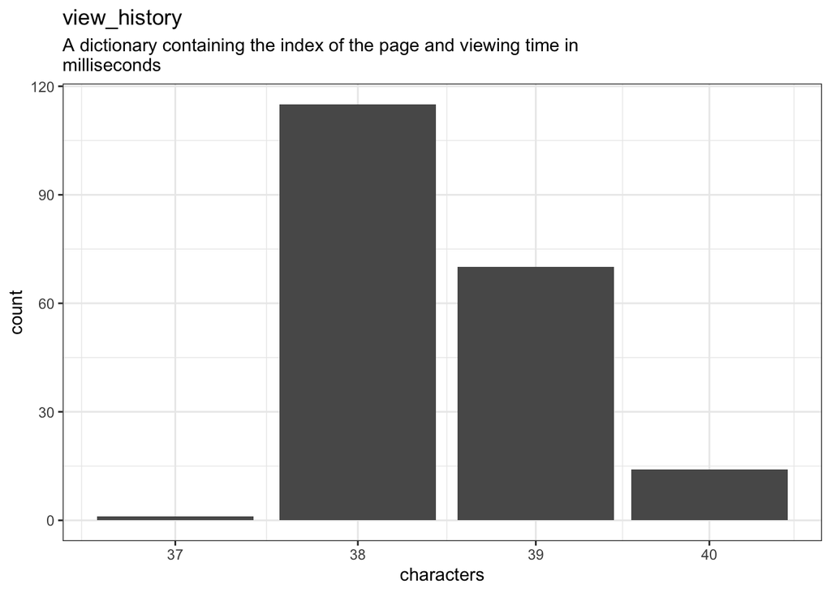

Distribution of values for view_history

1000 missing values.

#### 1.1.10.2 Summary statistics

| name | label | data_type | n_missing | complete_rate | n_unique | empty | min | max | whitespace |
| --- | --- | --- | --- | --- | --- | --- | --- | --- | --- |
| view_history | A dictionary containing the index of the page and viewing time in milliseconds | character | 1000 | 0.1666667 | 198 | 0 | 37 | 40 | 0 |

### 1.1.11 init_locations

For the Sorting Task, a dictionary describing initial x and y locations of each item and the item name

#### 1.1.11.1 Distribution

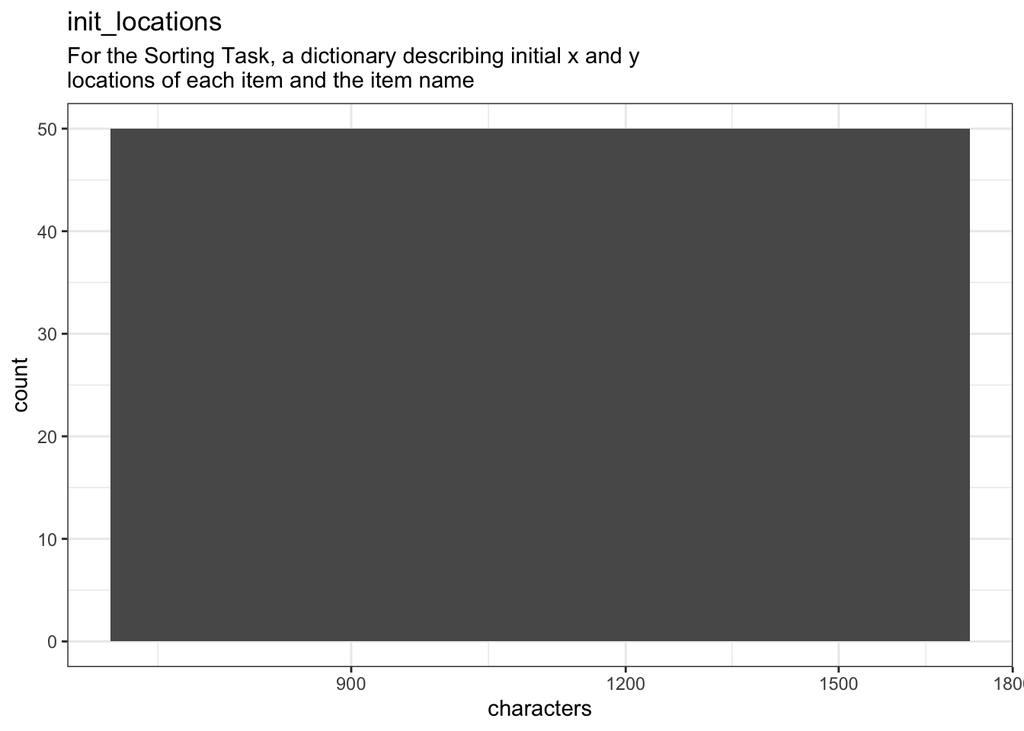

Distribution of values for init_locations

1150 missing values.

#### 1.1.11.2 Summary statistics

| name | label | data_type | n_missing | complete_rate | n_unique | empty | min | max | whitespace |
| --- | --- | --- | --- | --- | --- | --- | --- | --- | --- |
| init_locations | For the Sorting Task, a dictionary describing initial x and y locations of each item and the item name | character | 1150 | 0.0416667 | 50 | 0 | 1097 | 1097 | 0 |

### 1.1.12 moves

For the Sorting Task, a dictionary describing where x and y locations of where items were moved to

#### 1.1.12.1 Distribution

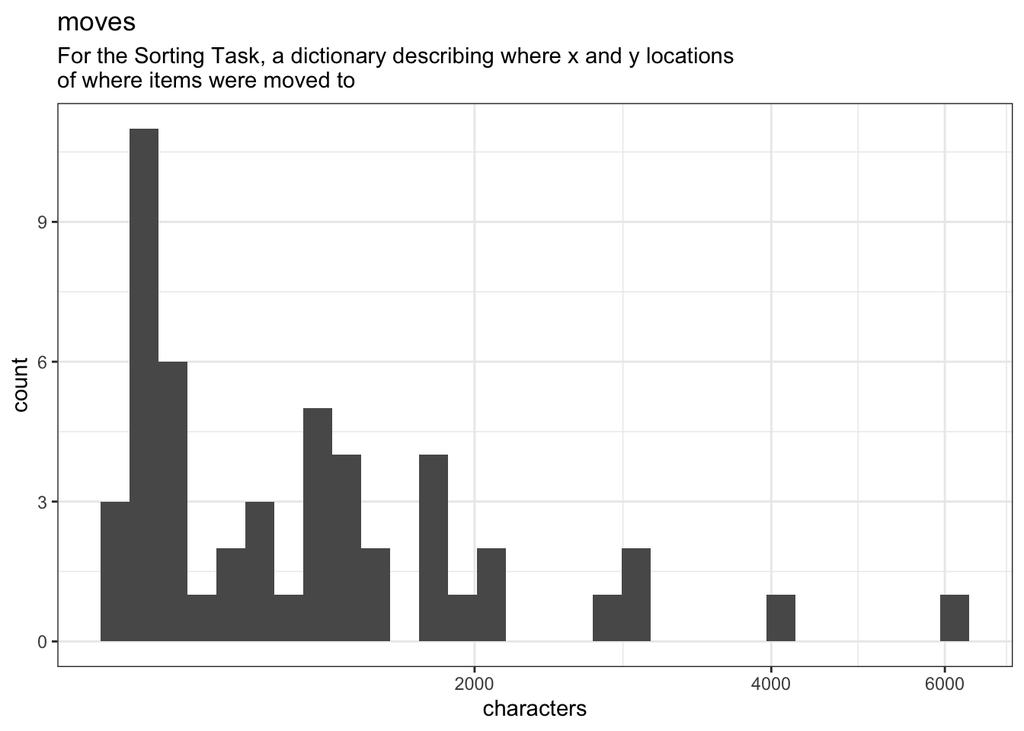

Distribution of values for moves

1150 missing values.

#### 1.1.12.2 Summary statistics

| name | label | data_type | n_missing | complete_rate | n_unique | empty | min | max | whitespace |
| --- | --- | --- | --- | --- | --- | --- | --- | --- | --- |
| moves | For the Sorting Task, a dictionary describing where x and y locations of where items were moved to | character | 1150 | 0.0416667 | 50 | 0 | 842 | 5990 | 0 |

### 1.1.13 final_locations

For the Sorting Task, a dictionary describing final x and y locations of each item and the item name

#### 1.1.13.1 Distribution

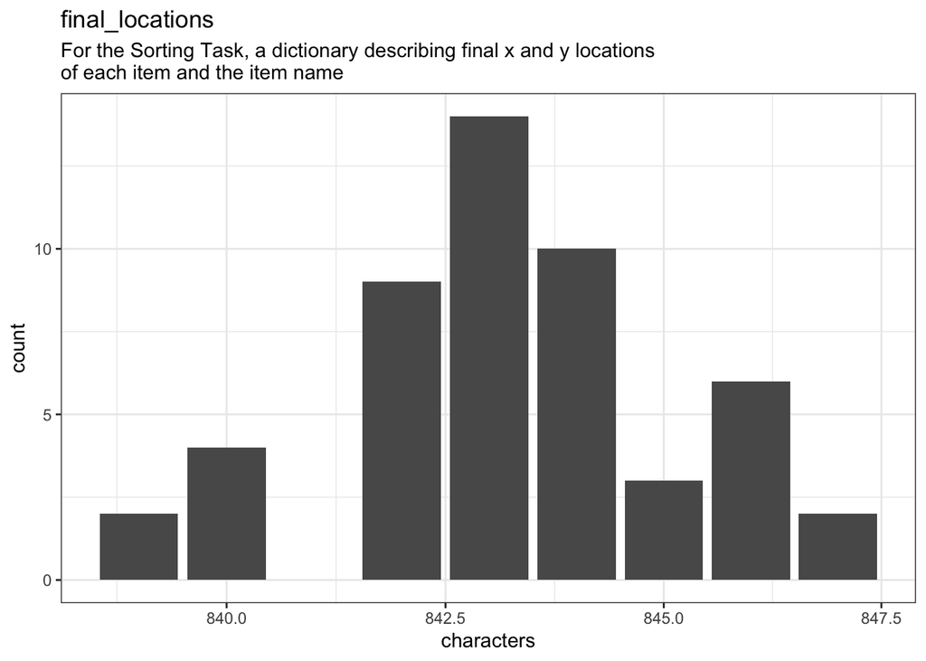

Distribution of values for final_locations

1150 missing values.

#### 1.1.13.2 Summary statistics

| name | label | data_type | n_missing | complete_rate | n_unique | empty | min | max | whitespace |
| --- | --- | --- | --- | --- | --- | --- | --- | --- | --- |
| final_locations | For the Sorting Task, a dictionary describing final x and y locations of each item and the item name | character | 1150 | 0.0416667 | 50 | 0 | 839 | 847 | 0 |

### 1.1.14 0

For the Sorting Task, a dictionary describing metadata about the first pair of items subjects saw

#### 1.1.14.1 Distribution

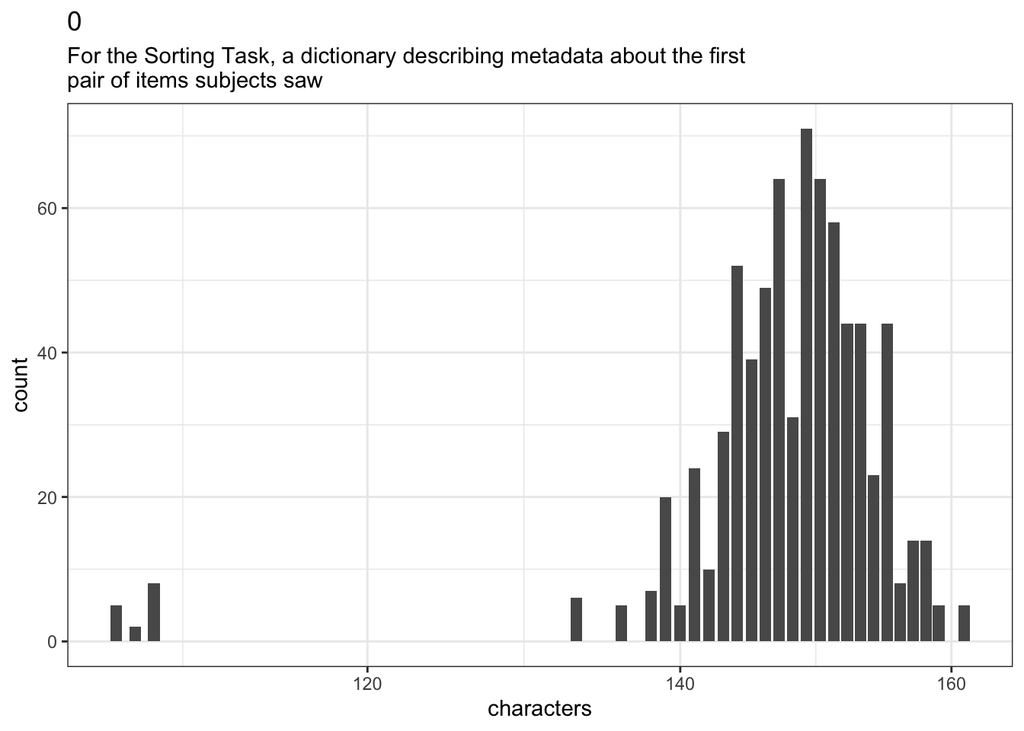

Distribution of values for 0

450 missing values.

#### 1.1.14.2 Summary statistics

| name | label | data_type | n_missing | complete_rate | n_unique | empty | min | max | whitespace |
| --- | --- | --- | --- | --- | --- | --- | --- | --- | --- |
| 0 | For the Sorting Task, a dictionary describing metadata about the first pair of items subjects saw | character | 450 | 0.625 | 217 | 0 | 106 | 161 | 0 |

### 1.1.15 1

For the Sorting Task, a dictionary describing metadata about the second pair of items subjects saw

#### 1.1.15.1 Distribution

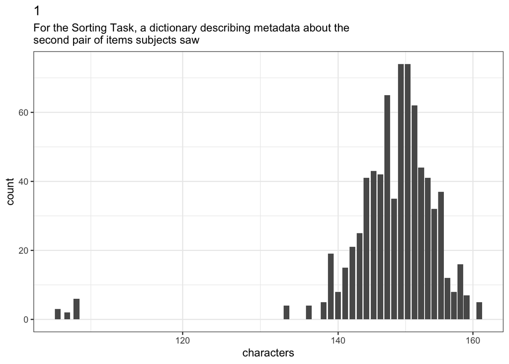

Distribution of values for 1

450 missing values.

#### 1.1.15.2 Summary statistics

| name | label | data_type | n_missing | complete_rate | n_unique | empty | min | max | whitespace |
| --- | --- | --- | --- | --- | --- | --- | --- | --- | --- |
| 1 | For the Sorting Task, a dictionary describing metadata about the second pair of items subjects saw | character | 450 | 0.625 | 220 | 0 | 106 | 161 | 0 |

### 1.1.16 2

For the Sorting Task, a dictionary describing metadata about the third pair of items subjects saw

#### 1.1.16.1 Distribution

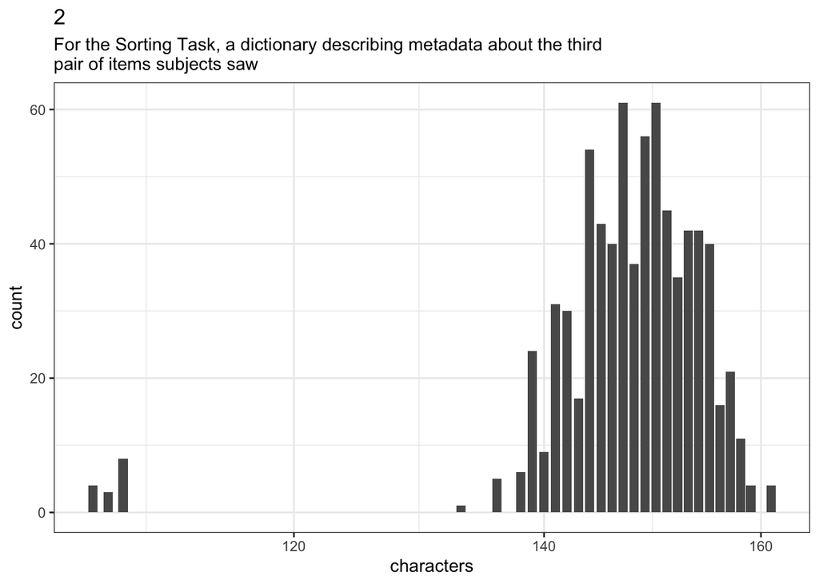

Distribution of values for 2

450 missing values.

#### 1.1.16.2 Summary statistics

| name | label | data_type | n_missing | complete_rate | n_unique | empty | min | max | whitespace |
| --- | --- | --- | --- | --- | --- | --- | --- | --- | --- |
| 2 | For the Sorting Task, a dictionary describing metadata about the third pair of items subjects saw | character | 450 | 0.625 | 218 | 0 | 106 | 161 | 0 |

### 1.1.17 3

For the Sorting Task, a dictionary describing metadata about the fourth pair of items subjects saw

#### 1.1.17.1 Distribution

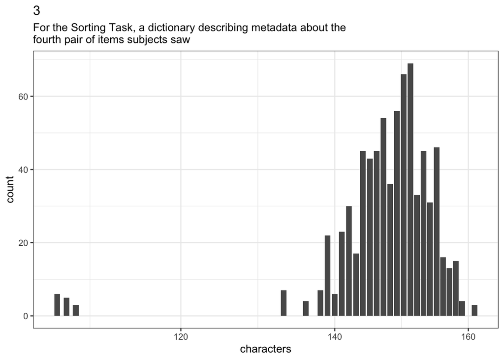

Distribution of values for 3

450 missing values.

#### 1.1.17.2 Summary statistics

| name | label | data_type | n_missing | complete_rate | n_unique | empty | min | max | whitespace |
| --- | --- | --- | --- | --- | --- | --- | --- | --- | --- |
| 3 | For the Sorting Task, a dictionary describing metadata about the fourth pair of items subjects saw | character | 450 | 0.625 | 219 | 0 | 106 | 161 | 0 |

### 1.1.18 4

For the Sorting Task, a dictionary describing metadata about the fifth pair of items subjects saw

#### 1.1.18.1 Distribution

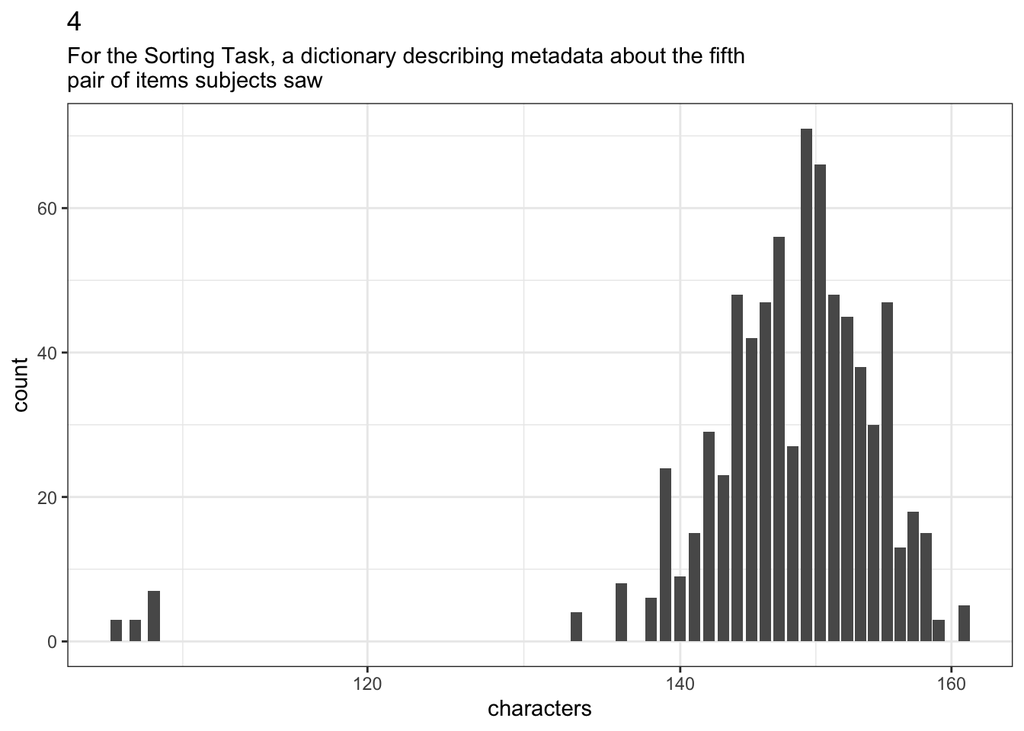

Distribution of values for 4

450 missing values.

#### 1.1.18.2 Summary statistics

| name | label | data_type | n_missing | complete_rate | n_unique | empty | min | max | whitespace |
| --- | --- | --- | --- | --- | --- | --- | --- | --- | --- |
| 4 | For the Sorting Task, a dictionary describing metadata about the fifth pair of items subjects saw | character | 450 | 0.625 | 221 | 0 | 106 | 161 | 0 |

### 1.1.19 5

For the Sorting Task, a dictionary describing metadata about the sixth pair of items subjects saw

#### 1.1.19.1 Distribution

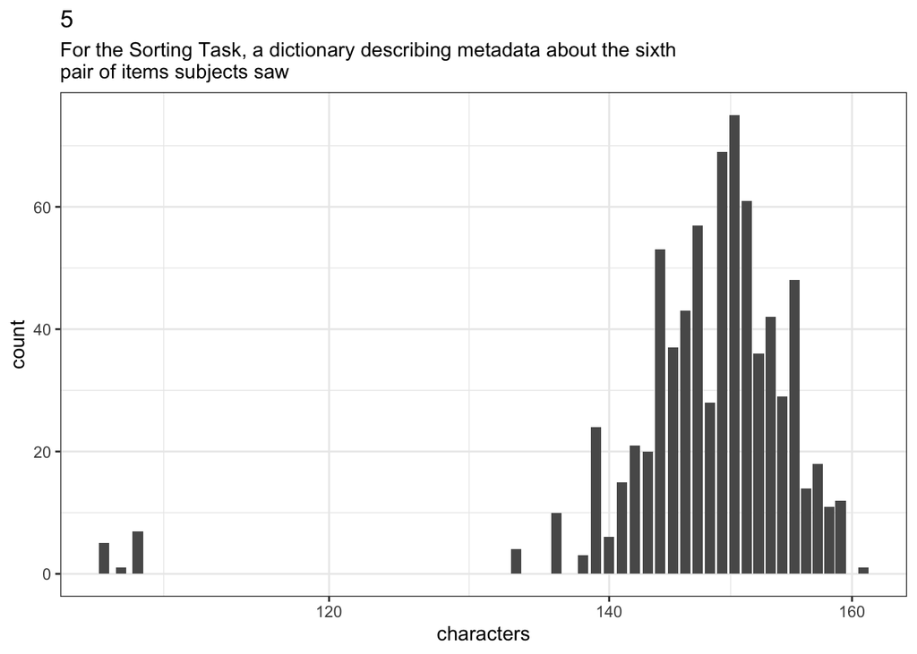

Distribution of values for 5

450 missing values.

#### 1.1.19.2 Summary statistics

| name | label | data_type | n_missing | complete_rate | n_unique | empty | min | max | whitespace |
| --- | --- | --- | --- | --- | --- | --- | --- | --- | --- |
| 5 | For the Sorting Task, a dictionary describing metadata about the sixth pair of items subjects saw | character | 450 | 0.625 | 226 | 0 | 106 | 161 | 0 |

### 1.1.20 6

For the Sorting Task, a dictionary describing metadata about the seventh pair of items subjects saw

#### 1.1.20.1 Distribution

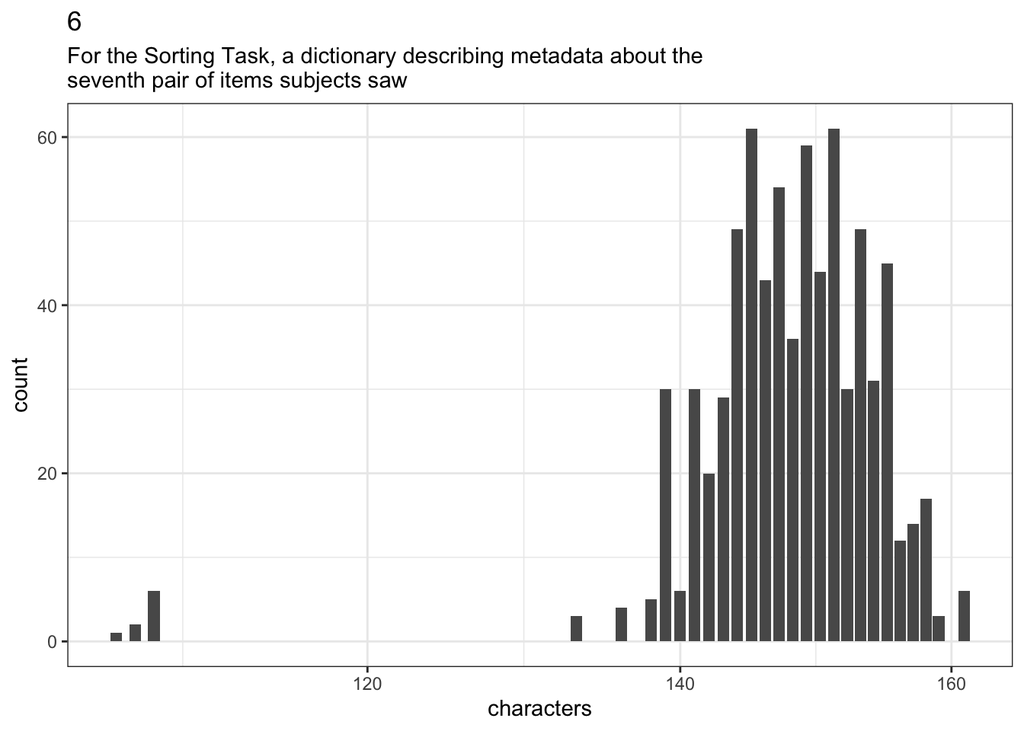

Distribution of values for 6

450 missing values.

#### 1.1.20.2 Summary statistics

| name | label | data_type | n_missing | complete_rate | n_unique | empty | min | max | whitespace |
| --- | --- | --- | --- | --- | --- | --- | --- | --- | --- |
| 6 | For the Sorting Task, a dictionary describing metadata about the seventh pair of items subjects saw | character | 450 | 0.625 | 221 | 0 | 106 | 161 | 0 |

### 1.1.21 7

For the Sorting Task, a dictionary describing metadata about the eighth pair of items subjects saw

#### 1.1.21.1 Distribution

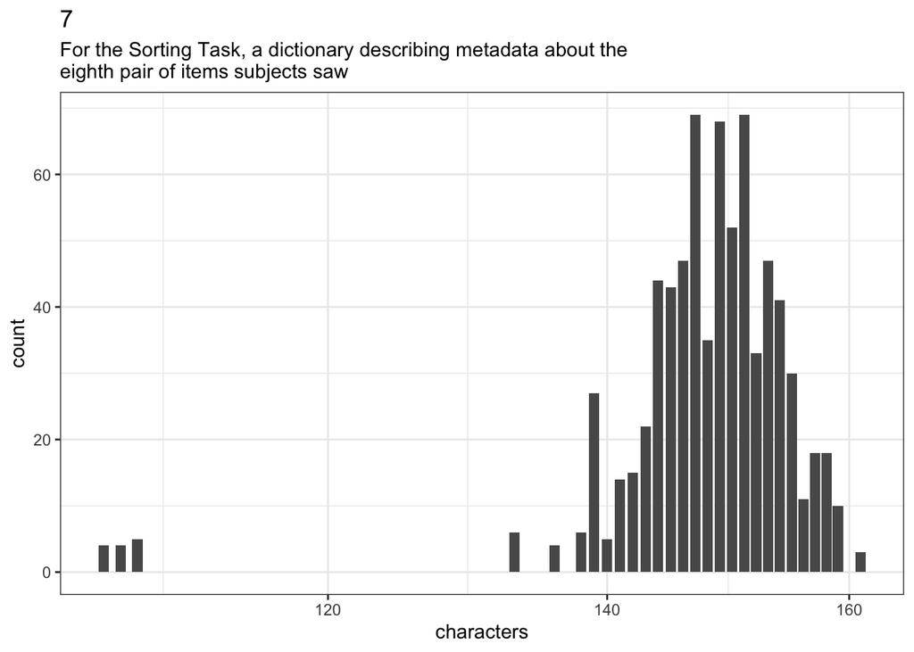

Distribution of values for 7

450 missing values.

#### 1.1.21.2 Summary statistics

| name | label | data_type | n_missing | complete_rate | n_unique | empty | min | max | whitespace |
| --- | --- | --- | --- | --- | --- | --- | --- | --- | --- |
| 7 | For the Sorting Task, a dictionary describing metadata about the eighth pair of items subjects saw | character | 450 | 0.625 | 223 | 0 | 106 | 161 | 0 |

### 1.1.22 8

#### 1.1.22.1 Distribution

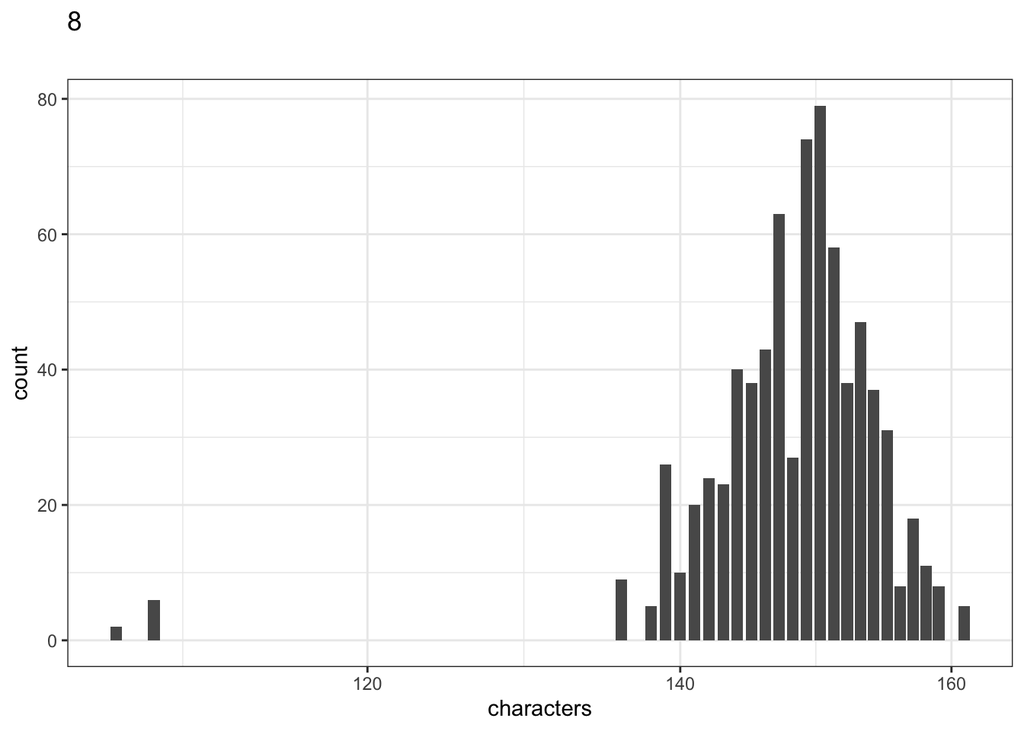

Distribution of values for 8

450 missing values.

#### 1.1.22.2 Summary statistics

| name | data_type | n_missing | complete_rate | n_unique | empty | min | max | whitespace | label |
| --- | --- | --- | --- | --- | --- | --- | --- | --- | --- |
| 8 | character | 450 | 0.625 | 219 | 0 | 106 | 161 | 0 | NA |

### 1.1.23 9

For the Sorting Task, a dictionary describing metadata about the ninth pair of items subjects saw

#### 1.1.23.1 Distribution

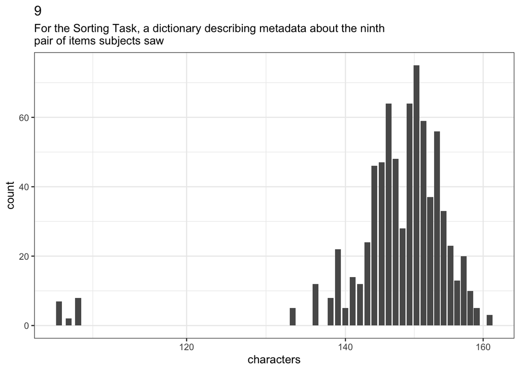

Distribution of values for 9

450 missing values.

#### 1.1.23.2 Summary statistics

| name | label | data_type | n_missing | complete_rate | n_unique | empty | min | max | whitespace |
| --- | --- | --- | --- | --- | --- | --- | --- | --- | --- |
| 9 | For the Sorting Task, a dictionary describing metadata about the ninth pair of items subjects saw | character | 450 | 0.625 | 223 | 0 | 106 | 161 | 0 |

### 1.1.24 10

For the Sorting Task, a dictionary describing metadata about the tenth pair of items subjects saw

#### 1.1.24.1 Distribution

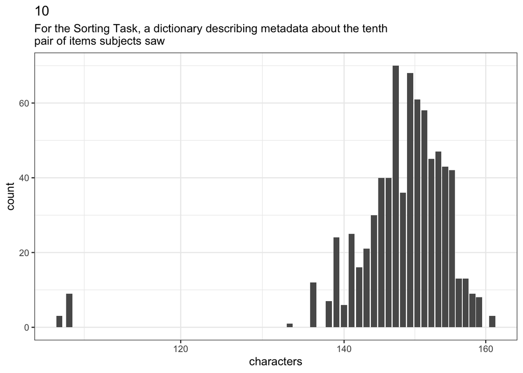

Distribution of values for 10

450 missing values.

#### 1.1.24.2 Summary statistics

| name | label | data_type | n_missing | complete_rate | n_unique | empty | min | max | whitespace |
| --- | --- | --- | --- | --- | --- | --- | --- | --- | --- |
| 10 | For the Sorting Task, a dictionary describing metadata about the tenth pair of items subjects saw | character | 450 | 0.625 | 217 | 0 | 107 | 161 | 0 |

### 1.1.25 11

For the Sorting Task, a dictionary describing metadata about the eleventh pair of items subjects saw

#### 1.1.25.1 Distribution

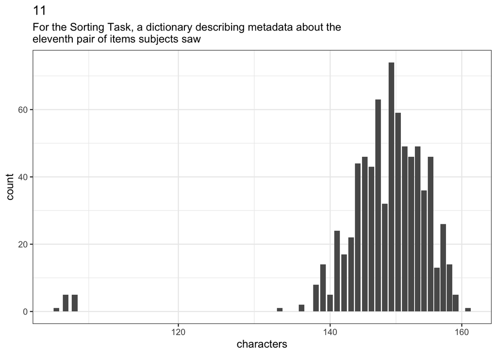

Distribution of values for 11

450 missing values.

#### 1.1.25.2 Summary statistics

| name | label | data_type | n_missing | complete_rate | n_unique | empty | min | max | whitespace |
| --- | --- | --- | --- | --- | --- | --- | --- | --- | --- |
| 11 | For the Sorting Task, a dictionary describing metadata about the eleventh pair of items subjects saw | character | 450 | 0.625 | 222 | 0 | 106 | 161 | 0 |

### 1.1.26 12

For the Sorting Task, a dictionary describing metadata about the twelfth pair of items subjects saw

#### 1.1.26.1 Distribution

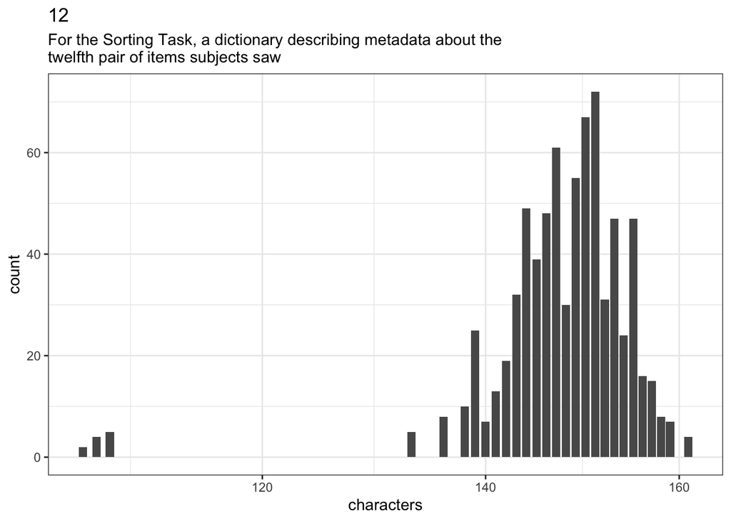

Distribution of values for 12

450 missing values.

#### 1.1.26.2 Summary statistics

| name | label | data_type | n_missing | complete_rate | n_unique | empty | min | max | whitespace |
| --- | --- | --- | --- | --- | --- | --- | --- | --- | --- |
| 12 | For the Sorting Task, a dictionary describing metadata about the twelfth pair of items subjects saw | character | 450 | 0.625 | 219 | 0 | 106 | 161 | 0 |

### 1.1.27 13

For the Sorting Task, a dictionary describing metadata about the thirtheenth pair of items subjects saw

#### 1.1.27.1 Distribution

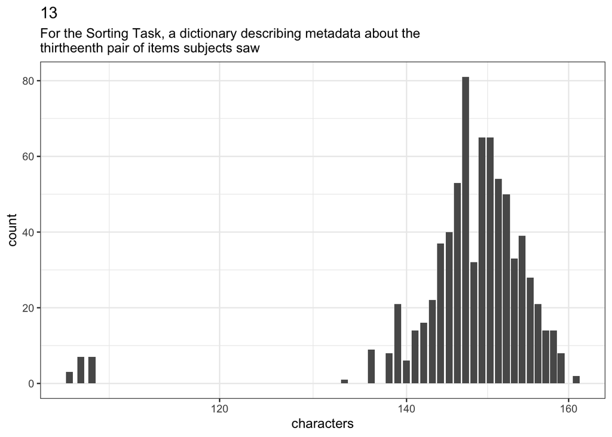

Distribution of values for 13

450 missing values.

#### 1.1.27.2 Summary statistics

| name | label | data_type | n_missing | complete_rate | n_unique | empty | min | max | whitespace |
| --- | --- | --- | --- | --- | --- | --- | --- | --- | --- |
| 13 | For the Sorting Task, a dictionary describing metadata about the thirtheenth pair of items subjects saw | character | 450 | 0.625 | 215 | 0 | 106 | 161 | 0 |

### 1.1.28 14

For the Sorting Task, a dictionary describing metadata about the fourtheenth pair of items subjects saw

#### 1.1.28.1 Distribution

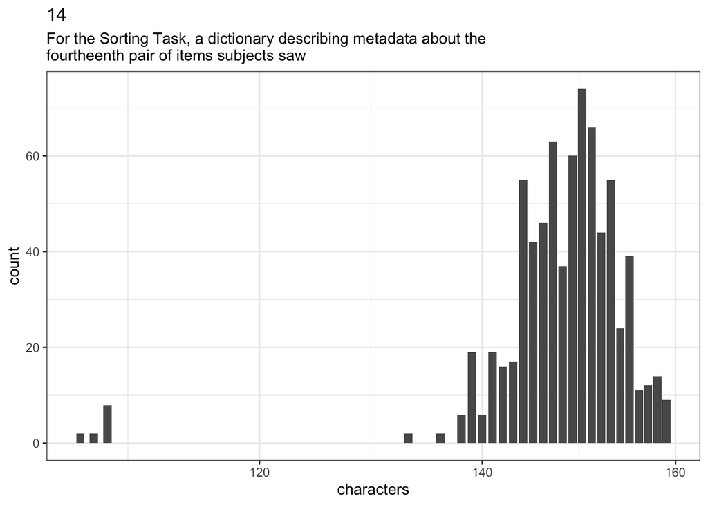

Distribution of values for 14

450 missing values.

#### 1.1.28.2 Summary statistics

| name | label | data_type | n_missing | complete_rate | n_unique | empty | min | max | whitespace |
| --- | --- | --- | --- | --- | --- | --- | --- | --- | --- |
| 14 | For the Sorting Task, a dictionary describing metadata about the fourtheenth pair of items subjects saw | character | 450 | 0.625 | 219 | 0 | 106 | 159 | 0 |

### 1.1.29 question_order

The order of questions seen by subjects

#### 1.1.29.1 Distribution

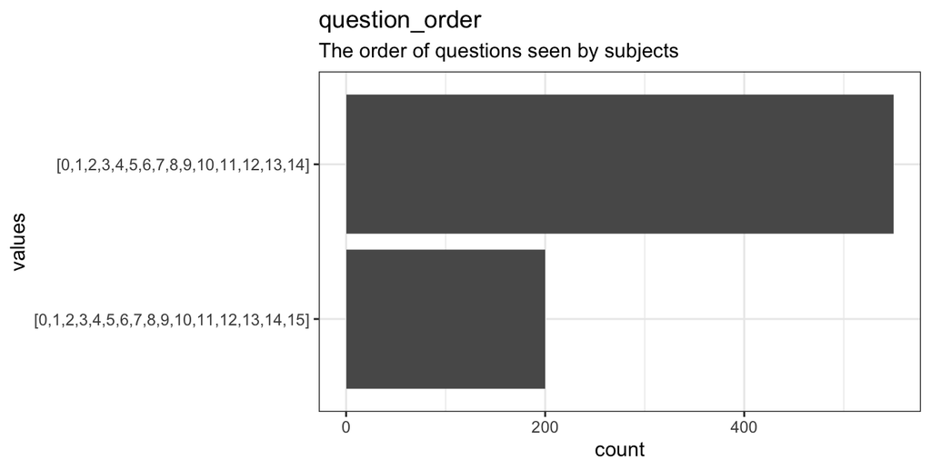

Distribution of values for question_order

450 missing values.

#### 1.1.29.2 Summary statistics

| name | label | data_type | n_missing | complete_rate | n_unique | empty | min | max | whitespace |
| --- | --- | --- | --- | --- | --- | --- | --- | --- | --- |
| question_order | The order of questions seen by subjects | character | 450 | 0.625 | 2 | 0 | 36 | 39 | 0 |

### 1.1.30 15

#### 1.1.30.1 Distribution

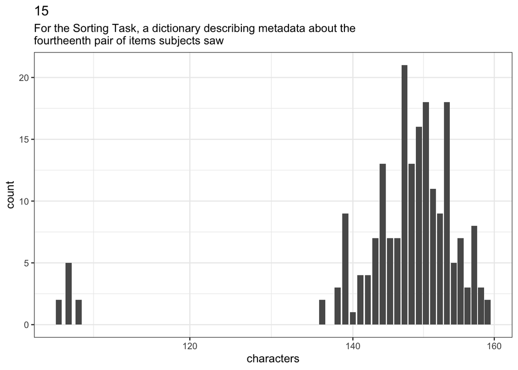

Distribution of values for 15

1000 missing values.

#### 1.1.30.2 Summary statistics

[output not shown]

### 1.1.31 feedback

feedback provided by subjects

#### 1.1.31.1 Distribution

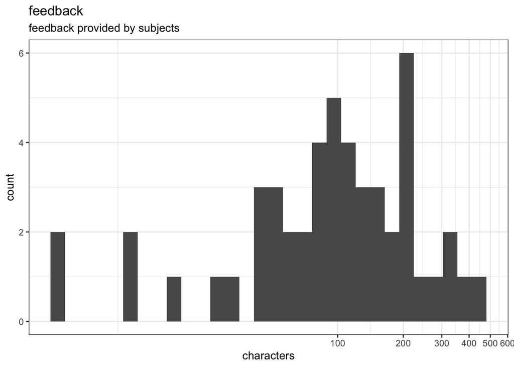

Distribution of values for feedback

1150 missing values.

#### 1.1.31.2 Summary statistics

| name | label | data_type | n_missing | complete_rate | n_unique | empty | min | max | whitespace |
| --- | --- | --- | --- | --- | --- | --- | --- | --- | --- |
| feedback | feedback provided by subjects | character | 1150 | 0.0416667 | 49 | 0 | 4 | 416 | 0 |

### 1.1.32 age

#### 1.1.32.1 Distribution

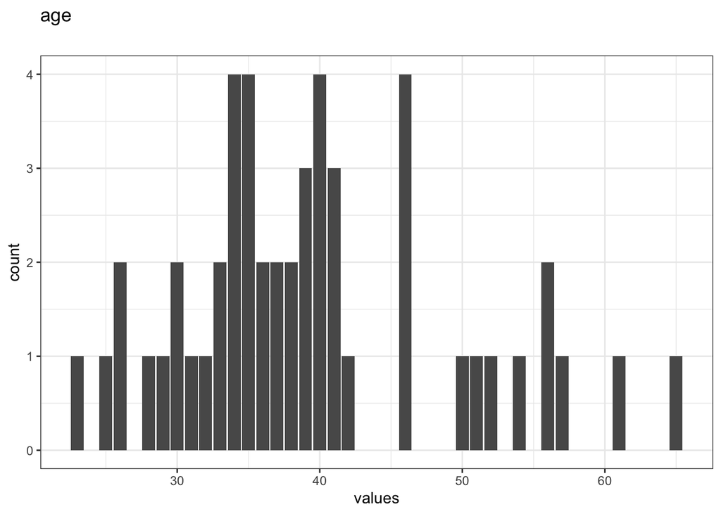

Distribution of values for age

1150 missing values.

#### 1.1.32.2 Summary statistics

| name | data_type | n_missing | complete_rate | min | median | max | mean | sd | hist | label |
| --- | --- | --- | --- | --- | --- | --- | --- | --- | --- | --- |
| age | numeric | 1150 | 0.0416667 | 23 | 38 | 65 | 39.44 | 9.564304 | ▃▇▅▂▁ | NA |

### 1.1.33 ethnicity

#### 1.1.33.1 Distribution

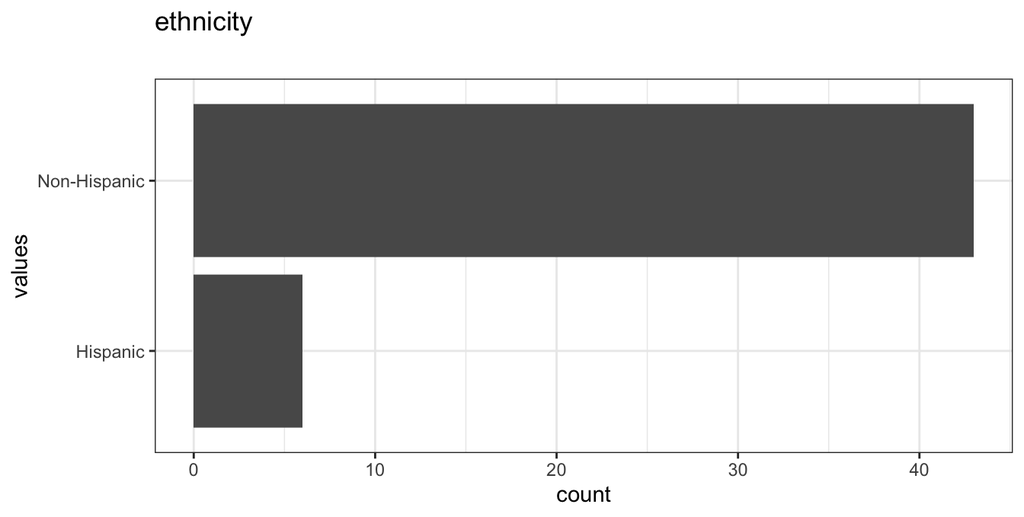

Distribution of values for ethnicity

1151 missing values.

#### 1.1.33.2 Summary statistics

| name | data_type | n_missing | complete_rate | n_unique | empty | min | max | whitespace | label |
| --- | --- | --- | --- | --- | --- | --- | --- | --- | --- |
| ethnicity | character | 1151 | 0.0408333 | 2 | 0 | 8 | 12 | 0 | NA |

### 1.1.34 gender

#### 1.1.34.1 Distribution

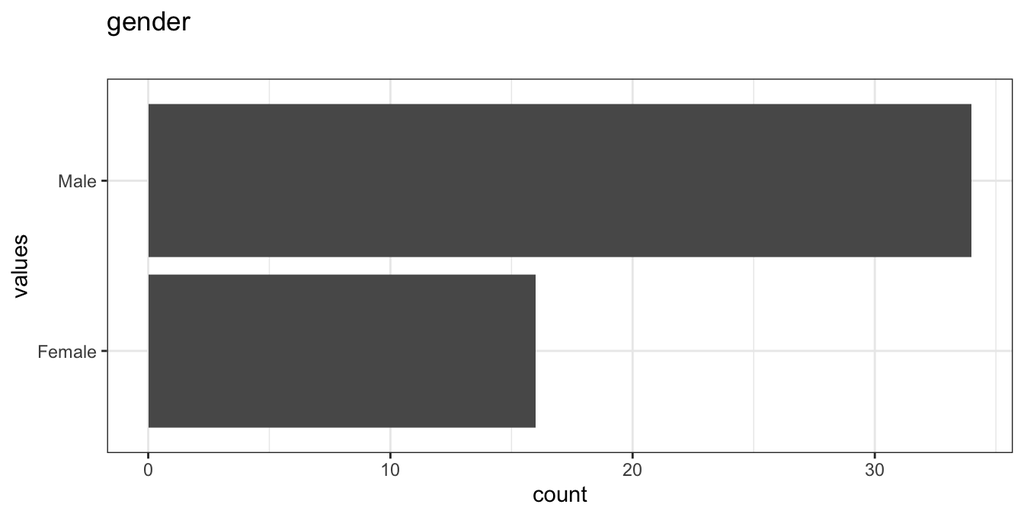

Distribution of values for gender

1150 missing values.

#### 1.1.34.2 Summary statistics

| name | data_type | n_missing | complete_rate | n_unique | empty | min | max | whitespace | label |
| --- | --- | --- | --- | --- | --- | --- | --- | --- | --- |
| gender | character | 1150 | 0.0416667 | 2 | 0 | 4 | 6 | 0 | NA |

### 1.1.35 race

#### 1.1.35.1 Distribution

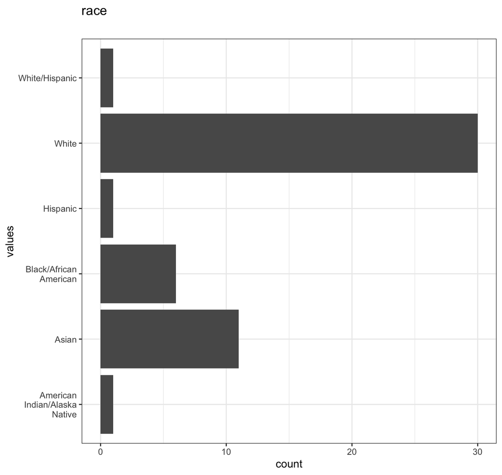

Distribution of values for race

1150 missing values.

#### 1.1.35.2 Summary statistics

| name | data_type | n_missing | complete_rate | n_unique | empty | min | max | whitespace | label |
| --- | --- | --- | --- | --- | --- | --- | --- | --- | --- |
| race | character | 1150 | 0.0416667 | 6 | 0 | 5 | 29 | 0 | NA |

## 1.2 Missingness report

| description | rt | response | 0 | 1 | 2 | 3 | 4 | 5 | 6 | 7 | 8 | 9 | 10 | 11 | 12 | 13 | 14 | question_order | view_history | 15 | trial_id | stimulus | init_locations | moves | final_locations | feedback | age | gender | race | … |
| --- | --- | --- | --- | --- | --- | --- | --- | --- | --- | --- | --- | --- | --- | --- | --- | --- | --- | --- | --- | --- | --- | --- | --- | --- | --- | --- | --- | --- | --- | --- |
| Missing values per variable | 50 | 300 | 450 | 450 | 450 | 450 | 450 | 450 | 450 | 450 | 450 | 450 | 450 | 450 | 450 | 450 | 450 | 450 | 1000 | 1000 | 1050 | 1100 | 1150 | 1150 | 1150 | 1150 | 1150 | 1150 | 1150 | … |
| Missing values in 12 variables | 1 | 1 | 1 | 1 | 1 | 1 | 1 | 1 | 1 | 1 | 1 | 1 | 1 | 1 | 1 | 1 | 1 | 1 | 0 | 0 | 0 | 0 | 0 | 0 | 0 | 0 | 0 | 0 | 0 | … |
| Missing values in 11 variables | 1 | 1 | 1 | 1 | 1 | 1 | 1 | 1 | 1 | 1 | 1 | 1 | 1 | 1 | 1 | 1 | 1 | 1 | 0 | 1 | 0 | 0 | 0 | 0 | 0 | 0 | 0 | 0 | 0 | … |
| Missing values in 28 variables | 1 | 0 | 0 | 0 | 0 | 0 | 0 | 0 | 0 | 0 | 0 | 0 | 0 | 0 | 0 | 0 | 0 | 0 | 1 | 0 | 0 | 0 | 0 | 0 | 0 | 0 | 0 | 0 | 0 | … |
| Missing values in 26 variables | 1 | 1 | 0 | 0 | 0 | 0 | 0 | 0 | 0 | 0 | 0 | 0 | 0 | 0 | 0 | 0 | 0 | 0 | 0 | 0 | 1 | 1 | 0 | 0 | 0 | 0 | 0 | 0 | 0 | … |
| Missing values in 26 variables | 1 | 0 | 0 | 0 | 0 | 0 | 0 | 0 | 0 | 0 | 0 | 0 | 0 | 0 | 0 | 0 | 0 | 0 | 0 | 0 | 0 | 0 | 1 | 1 | 1 | 0 | 0 | 0 | 0 | … |
| Missing values in 30 variables | 0 | 0 | 0 | 0 | 0 | 0 | 0 | 0 | 0 | 0 | 0 | 0 | 0 | 0 | 0 | 0 | 0 | 0 | 0 | 0 | 0 | 0 | 0 | 0 | 0 | 0 | 0 | 0 | 0 | … |
| Missing values in 22 variables | 1 | 1 | 0 | 0 | 0 | 0 | 0 | 0 | 0 | 0 | 0 | 0 | 0 | 0 | 0 | 0 | 0 | 0 | 0 | 0 | 1 | 0 | 0 | 0 | 0 | 1 | 1 | 1 | 1 | … |
| 1 other, less frequent patterns | 1 | 1 | 0 | 0 | 0 | 0 | 0 | 0 | 0 | 0 | 0 | 0 | 0 | 0 | 0 | 0 | 0 | 0 | 0 | 0 | 1 | 0 | 0 | 0 | 0 | 1 | 1 | 1 | 1 | … |

## 1.3 Codebook table

| name | label | data_type | ordered | value_labels | n_missing | complete_rate | n_unique | empty | top_counts | min | median | max | mean | sd | whitespace | hist |
| --- | --- | --- | --- | --- | --- | --- | --- | --- | --- | --- | --- | --- | --- | --- | --- | --- |
| subject_id | Subject ids for all 50 subjects | factor | FALSE | 1. subj_01, 2. subj_02, 3. subj_03, 4. subj_04, 5. subj_05, 6. subj_06, 7. subj_07, 8. subj_08, 9. subj_09, 10. subj_10, 11. subj_11, 12. subj_12, 13. subj_13, 14. subj_14, 15. subj_15, 16. subj_16, 1… | 0 | 1.0000000 | 50 | NA | sub: 24, sub: 24, sub: 24, sub: 24 | NA | NA | NA | NA | NA | NA | NA |
| trial_type | Type of jspsych trial. Trials in jspsych represent checkpoints in the experiment, such as the instructions page, the survey page etc | character | NA | NA | 0 | 1.0000000 | 7 | 0 | NA | 7 | NA | 21 | NA | NA | 0 | NA |
| trial_index | Each subject did about 23 trials (Note: trial in the jspsych sense, since this raw data. | numeric | NA | NA | 0 | 1.0000000 | NA | NA | NA | 0 | 12 | 23 | 11.50 | 6.925073e+00 | NA | ▇▇▆▇▇ |
| plugin_version | Plugin version that the subject had for the jspsych trials | character | NA | NA | 0 | 1.0000000 | 3 | 0 | NA | 4 | NA | 5 | NA | NA | 0 | NA |
| time_elapsed | Time in milliseconds the subject spent on a given trial | numeric | NA | NA | 0 | 1.0000000 | NA | NA | NA | 154 | 684924 | 5596441 | 965786.35 | 1.025307e+06 | NA | ▇▂▁▁▁ |
| trial_id | Researcher-assigned trial names. Trials highlighted were the consent, example_videos and demorgraphics_survey | character | NA | NA | 1050 | 0.1250000 | 3 | 0 | NA | 7 | NA | 19 | NA | NA | 0 | NA |
| rt | Time it takes in milliseconds from when the page loads to when subject clicks on continue button | numeric | NA | NA | 50 | 0.9583333 | NA | NA | NA | 906 | 51539 | 2425768 | 83171.52 | 1.479344e+05 | NA | ▇▁▁▁▁ |
| stimulus | Html-formatted string describing the stimulus presented to participant on trials that had a stimulus | character | NA | NA | 1100 | 0.0833333 | 2 | 0 | NA | 35 | NA | 1959 | NA | NA | 0 | NA |
| response | For the Causal Task, a dictionary containing subject responses for all 14 questions in each page | character | NA | NA | 300 | 0.7500000 | 801 | 0 | NA | 1 | NA | 540 | NA | NA | 0 | NA |
| view_history | A dictionary containing the index of the page and viewing time in milliseconds | character | NA | NA | 1000 | 0.1666667 | 198 | 0 | NA | 37 | NA | 40 | NA | NA | 0 | NA |
| init_locations | For the Sorting Task, a dictionary describing initial x and y locations of each item and the item name | character | NA | NA | 1150 | 0.0416667 | 50 | 0 | NA | 1097 | NA | 1097 | NA | NA | 0 | NA |
| moves | For the Sorting Task, a dictionary describing where x and y locations of where items were moved to | character | NA | NA | 1150 | 0.0416667 | 50 | 0 | NA | 842 | NA | 5990 | NA | NA | 0 | NA |
| final_locations | For the Sorting Task, a dictionary describing final x and y locations of each item and the item name | character | NA | NA | 1150 | 0.0416667 | 50 | 0 | NA | 839 | NA | 847 | NA | NA | 0 | NA |
| 0 | For the Sorting Task, a dictionary describing metadata about the first pair of items subjects saw | character | NA | NA | 450 | 0.6250000 | 217 | 0 | NA | 106 | NA | 161 | NA | NA | 0 | NA |
| 1 | For the Sorting Task, a dictionary describing metadata about the second pair of items subjects saw | character | NA | NA | 450 | 0.6250000 | 220 | 0 | NA | 106 | NA | 161 | NA | NA | 0 | NA |
| 2 | For the Sorting Task, a dictionary describing metadata about the third pair of items subjects saw | character | NA | NA | 450 | 0.6250000 | 218 | 0 | NA | 106 | NA | 161 | NA | NA | 0 | NA |
| 3 | For the Sorting Task, a dictionary describing metadata about the fourth pair of items subjects saw | character | NA | NA | 450 | 0.6250000 | 219 | 0 | NA | 106 | NA | 161 | NA | NA | 0 | NA |
| 4 | For the Sorting Task, a dictionary describing metadata about the fifth pair of items subjects saw | character | NA | NA | 450 | 0.6250000 | 221 | 0 | NA | 106 | NA | 161 | NA | NA | 0 | NA |
| 5 | For the Sorting Task, a dictionary describing metadata about the sixth pair of items subjects saw | character | NA | NA | 450 | 0.6250000 | 226 | 0 | NA | 106 | NA | 161 | NA | NA | 0 | NA |
| 6 | For the Sorting Task, a dictionary describing metadata about the seventh pair of items subjects saw | character | NA | NA | 450 | 0.6250000 | 221 | 0 | NA | 106 | NA | 161 | NA | NA | 0 | NA |
| 7 | For the Sorting Task, a dictionary describing metadata about the eighth pair of items subjects saw | character | NA | NA | 450 | 0.6250000 | 223 | 0 | NA | 106 | NA | 161 | NA | NA | 0 | NA |
| 8 | NA | character | NA | NA | 450 | 0.6250000 | 219 | 0 | NA | 106 | NA | 161 | NA | NA | 0 | NA |
| 9 | For the Sorting Task, a dictionary describing metadata about the ninth pair of items subjects saw | character | NA | NA | 450 | 0.6250000 | 223 | 0 | NA | 106 | NA | 161 | NA | NA | 0 | NA |
| 10 | For the Sorting Task, a dictionary describing metadata about the tenth pair of items subjects saw | character | NA | NA | 450 | 0.6250000 | 217 | 0 | NA | 107 | NA | 161 | NA | NA | 0 | NA |
| 11 | For the Sorting Task, a dictionary describing metadata about the eleventh pair of items subjects saw | character | NA | NA | 450 | 0.6250000 | 222 | 0 | NA | 106 | NA | 161 | NA | NA | 0 | NA |
| 12 | For the Sorting Task, a dictionary describing metadata about the twelfth pair of items subjects saw | character | NA | NA | 450 | 0.6250000 | 219 | 0 | NA | 106 | NA | 161 | NA | NA | 0 | NA |
| 13 | For the Sorting Task, a dictionary describing metadata about the thirtheenth pair of items subjects saw | character | NA | NA | 450 | 0.6250000 | 215 | 0 | NA | 106 | NA | 161 | NA | NA | 0 | NA |
| 14 | For the Sorting Task, a dictionary describing metadata about the fourtheenth pair of items subjects saw | character | NA | NA | 450 | 0.6250000 | 219 | 0 | NA | 106 | NA | 159 | NA | NA | 0 | NA |
| question_order | The order of questions seen by subjects | character | NA | NA | 450 | 0.6250000 | 2 | 0 | NA | 36 | NA | 39 | NA | NA | 0 | NA |
| 15 | For the Sorting Task, a dictionary describing metadata about the fourtheenth pair of items subjects saw | character | NA | NA | 1000 | 0.1666667 | 131 | 0 | NA | 106 | NA | 159 | NA | NA | 0 | NA |
| feedback | feedback provided by subjects | character | NA | NA | 1150 | 0.0416667 | 49 | 0 | NA | 4 | NA | 416 | NA | NA | 0 | NA |
| age | NA | numeric | NA | NA | 1150 | 0.0416667 | NA | NA | NA | 23 | 38 | 65 | 39.44 | 9.564304e+00 | NA | ▃▇▅▂▁ |
| ethnicity | NA | character | NA | NA | 1151 | 0.0408333 | 2 | 0 | NA | 8 | NA | 12 | NA | NA | 0 | NA |
| gender | NA | character | NA | NA | 1150 | 0.0416667 | 2 | 0 | NA | 4 | NA | 6 | NA | NA | 0 | NA |
| race | NA | character | NA | NA | 1150 | 0.0416667 | 6 | 0 | NA | 5 | NA | 29 | NA | NA | 0 | NA |

**JSON-LD metadata**

The following JSON-LD can be found by search engines, if you share this codebook publicly on the web.

```json
{
  "name": "Raw data for Study 1",
  "description": "This is the raw dataset for study 1 that will be used as input for the pre-processing script. Since this data is not yet preprocessed, and many of the variables are directly created by jspsych, the variables may not be immediately interpretable or relevant. There are 50 subject rows, and 24 rows per subject. Each row represents a jspsych trial.\n\n\n## Table of variables\nThis table contains variable names, labels, and number of missing values.\nSee the complete codebook for more.\n\n[truncated]\n\n### Note\nThis dataset was automatically described using the [codebook R package](https://rubenarslan.github.io/codebook/) (version 0.9.6).",
  "datePublished": "2025-02-03",
  "keywords": ["subject_id", "trial_type", "trial_index", "plugin_version", "time_elapsed", "trial_id", "rt", "stimulus", "response", "view_history", "init_locations", "moves", "final_locations", "0", "1", "2", "3", "4", "5", "6", "7", "8", "9", "10", "11", "12", "13", "14", "question_order", "15", "feedback", "age", "ethnicity", "gender", "race"],
  "@context": "https://schema.org/",
  "@type": "Dataset",
  "variableMeasured": [
    {
      "name": "subject_id",
      "description": "Subject ids for all 50 subjects",
      "value": "1. subj_01,\n2. subj_02,\n3. subj_03,\n4. subj_04,\n5. subj_05,\n6. subj_06,\n7. subj_07,\n8. subj_08,\n9. subj_09,\n10. subj_10,\n11. subj_11,\n12. subj_12,\n13. subj_13,\n14. subj_14,\n15. subj_15,\n16. subj_16,\n17. subj_17,\n18. subj_18,\n19. subj_19,\n20. subj_20,\n21. subj_21,\n22. subj_22,\n23. subj_23,\n24. subj_24,\n25. subj_25,\n26. subj_26,\n27. subj_27,\n28. subj_28,\n29. subj_29,\n30. subj_30,\n31. subj_31,\n32. subj_32,\n33. subj_33,\n34. subj_34,\n35. subj_35,\n36. subj_36,\n37. subj_37,\n38. subj_38,\n39. subj_39,\n40. subj_40,\n41. subj_41,\n42. subj_42,\n43. subj_43,\n44. subj_44,\n45. subj_45,\n46. subj_46,\n47. subj_47,\n48. subj_48,\n49. subj_49,\n50. subj_50",
      "@type": "propertyValue"
    },
    {
      "name": "trial_type",
      "description": "Type of jspsych trial. Trials in jspsych represent checkpoints in the experiment, such as the instructions page, the survey page etc ",
      "@type": "propertyValue"
    },
    {
      "name": "trial_index",
      "description": "Each subject did about 23 trials (Note: trial in the jspsych sense, since this raw data.",
      "@type": "propertyValue"
    },
    {
      "name": "plugin_version",
      "description": "Plugin version that the subject had for the jspsych trials",
      "@type": "propertyValue"
    },
    {
      "name": "time_elapsed",
      "description": "Time in milliseconds the subject spent on a given trial",
      "@type": "propertyValue"
    },
    {
      "name": "trial_id",
      "description": "Researcher-assigned trial names. Trials highlighted were the consent, example_videos and demorgraphics_survey",
      "@type": "propertyValue"
    },
    {
      "name": "rt",
      "description": "Time it takes in milliseconds from when the page loads to when subject clicks on continue button",
      "@type": "propertyValue"
    },
    {
      "name": "stimulus",
      "description": "Html-formatted string describing the stimulus presented to participant on trials that had a stimulus",
      "@type": "propertyValue"
    },
    {
      "name": "response",
      "description": "For the Causal Task, a dictionary containing subject responses for all 14 questions in each page",
      "@type": "propertyValue"
    },
    {
      "name": "view_history",
      "description": "A dictionary containing the index of the page and viewing time in milliseconds",
      "@type": "propertyValue"
    },
    {
      "name": "init_locations",
      "description": "For the Sorting Task, a dictionary describing initial x and y locations of each item and the item name",
      "@type": "propertyValue"
    },
    {
      "name": "moves",
      "description": "For the Sorting Task, a dictionary describing where x and y locations of where items were moved to",
      "@type": "propertyValue"
    },
    {
      "name": "final_locations",
      "description": "For the Sorting Task, a dictionary describing final x and y locations of each item and the item name",
      "@type": "propertyValue"
    },
    {
      "name": "0",
      "description": "For the Sorting Task, a dictionary describing metadata about the first pair of items subjects saw",
      "@type": "propertyValue"
    },
    {
      "name": "1",
      "description": "For the Sorting Task, a dictionary describing metadata about the second pair of items subjects saw",
      "@type": "propertyValue"
    },
    {
      "name": "2",
      "description": "For the Sorting Task, a dictionary describing metadata about the third pair of items subjects saw",
      "@type": "propertyValue"
    },
    {
      "name": "3",
      "description": "For the Sorting Task, a dictionary describing metadata about the fourth pair of items subjects saw",
      "@type": "propertyValue"
    },
    {
      "name": "4",
      "description": "For the Sorting Task, a dictionary describing metadata about the fifth pair of items subjects saw",
      "@type": "propertyValue"
    },
    {
      "name": "5",
      "description": "For the Sorting Task, a dictionary describing metadata about the sixth pair of items subjects saw",
      "@type": "propertyValue"
    },
    {
      "name": "6",
      "description": "For the Sorting Task, a dictionary describing metadata about the seventh pair of items subjects saw",
      "@type": "propertyValue"
    },
    {
      "name": "7",
      "description": "For the Sorting Task, a dictionary describing metadata about the eighth pair of items subjects saw",
      "@type": "propertyValue"
    },
    {
      "name": "8",
      "@type": "propertyValue"
    },
    {
      "name": "9",
      "description": "For the Sorting Task, a dictionary describing metadata about the ninth pair of items subjects saw",
      "@type": "propertyValue"
    },
    {
      "name": "10",
      "description": "For the Sorting Task, a dictionary describing metadata about the tenth pair of items subjects saw",
      "@type": "propertyValue"
    },
    {
      "name": "11",
      "description": "For the Sorting Task, a dictionary describing metadata about the eleventh pair of items subjects saw",
      "@type": "propertyValue"
    },
    {
      "name": "12",
      "description": "For the Sorting Task, a dictionary describing metadata about the twelfth pair of items subjects saw",
      "@type": "propertyValue"
    },
    {
      "name": "13",
      "description": "For the Sorting Task, a dictionary describing metadata about the thirtheenth pair of items subjects saw",
      "@type": "propertyValue"
    },
    {
      "name": "14",
      "description": "For the Sorting Task, a dictionary describing metadata about the fourtheenth pair of items subjects saw",
      "@type": "propertyValue"
    },
    {
      "name": "question_order",
      "description": "The order of questions seen by subjects",
      "@type": "propertyValue"
    },
    {
      "name": "15",
      "description": "For the Sorting Task, a dictionary describing metadata about the fourtheenth pair of items subjects saw",
      "@type": "propertyValue"
    },
    {
      "name": "feedback",
      "description": "feedback provided by subjects",
      "@type": "propertyValue"
    },
    {
      "name": "age",
      "@type": "propertyValue"
    },
    {
      "name": "ethnicity",
      "@type": "propertyValue"
    },
    {
      "name": "gender",
      "@type": "propertyValue"
    },
    {
      "name": "race",
      "@type": "propertyValue"
    }
  ]
}`
```